# Timeseries_Emery

The primary objectives of the workshop: 1. Create a time series object. 2. Decompose a time series. 3. Test for stationarity and detecting autocorrelation. 4. Choose the order of an ARIMA model. 5. Use explanatory series to improve models.

Library and Data

```r
library(forecast)
library(forecast)
library(xts)
```

Part 1: 1. Create Timeseries objects:

Visualize data:

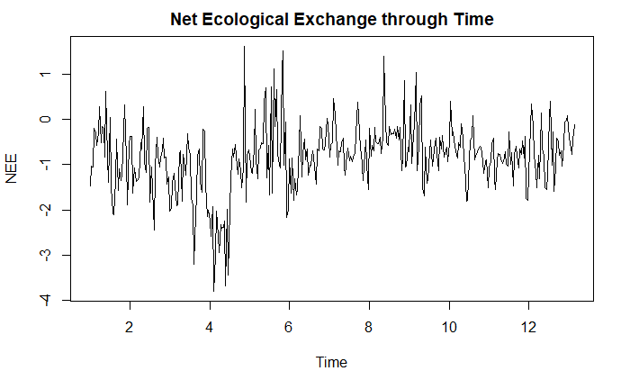

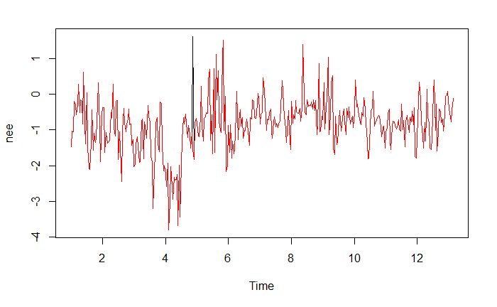

2. Decompose the timeseries:

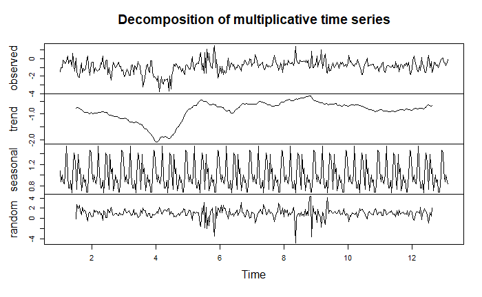

3.a. Test for stationarity

```r
# p-value < 0.05 indicates the TS is stationary
adf.test(nee )
```

```
p-value smaller than printed p-value
```

```
    Augmented Dickey-Fuller Test

data:  nee
Dickey-Fuller = -4.4703, Lag order = 7, p-value = 0.01
alternative hypothesis: stationary
```

3.b. Detecting Autocorrelation:

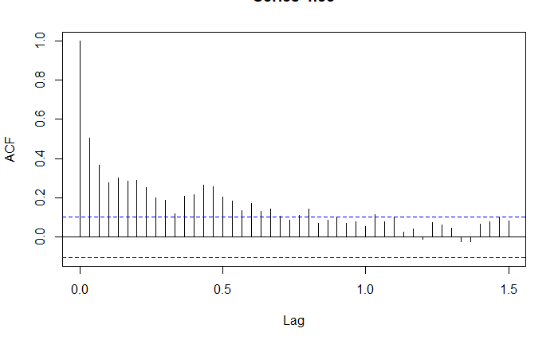

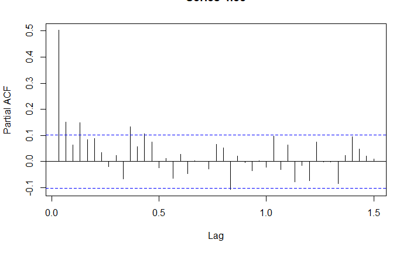

4. Fitting an ARIMA Model:

```r
arima.nee1 <-auto.arima(nee, trace=TRUE)
```

```
 Fitting models using approximations to speed things up...

 ARIMA(2,1,2)(1,0,1)[30] with drift         : 692.3276
 ARIMA(0,1,0)            with drift         : 812.1839
 ARIMA(1,1,0)(1,0,0)[30] with drift         : 754.1
 ARIMA(0,1,1)(0,0,1)[30] with drift         : 716.6018
 ARIMA(0,1,0)                               : 810.171
 ARIMA(2,1,2)(0,0,1)[30] with drift         : 700.2522
 ARIMA(2,1,2)(1,0,0)[30] with drift         : 690.6777
 ARIMA(2,1,2)            with drift         : 699.6979
 ARIMA(2,1,2)(2,0,0)[30] with drift         : 693.2668
 ARIMA(2,1,2)(2,0,1)[30] with drift         : 683.2512
 ARIMA(2,1,2)(2,0,2)[30] with drift         : 684.2198
 ARIMA(2,1,2)(1,0,2)[30] with drift         : 693.9678
 ARIMA(1,1,2)(2,0,1)[30] with drift         : 687.2495
 ARIMA(2,1,1)(2,0,1)[30] with drift         : 688.6439
 ARIMA(3,1,2)(2,0,1)[30] with drift         : 684.767
 ARIMA(2,1,3)(2,0,1)[30] with drift         : 680.7186
 ARIMA(2,1,3)(1,0,1)[30] with drift         : 691.8705
 ARIMA(2,1,3)(2,0,0)[30] with drift         : 693.7771
 ARIMA(2,1,3)(2,0,2)[30] with drift         : 680.1553
 ARIMA(2,1,3)(1,0,2)[30] with drift         : Inf
 ARIMA(1,1,3)(2,0,2)[30] with drift         : 685.9808
 ARIMA(3,1,3)(2,0,2)[30] with drift         : 687.4705
 ARIMA(2,1,4)(2,0,2)[30] with drift         : 682.0784
 ARIMA(1,1,2)(2,0,2)[30] with drift         : 688.6414
 ARIMA(1,1,4)(2,0,2)[30] with drift         : 687.389
 ARIMA(3,1,2)(2,0,2)[30] with drift         : Inf
 ARIMA(3,1,4)(2,0,2)[30] with drift         : Inf
 ARIMA(2,1,3)(2,0,2)[30]                    : 679.2322
 ARIMA(2,1,3)(1,0,2)[30]                    : 691.5612
 ARIMA(2,1,3)(2,0,1)[30]                    : 679.7025
 ARIMA(2,1,3)(1,0,1)[30]                    : 689.9659
 ARIMA(1,1,3)(2,0,2)[30]                    : Inf
 ARIMA(2,1,2)(2,0,2)[30]                    : 682.9001
 ARIMA(3,1,3)(2,0,2)[30]                    : 686.0237
 ARIMA(2,1,4)(2,0,2)[30]                    : 681.2665
 ARIMA(1,1,2)(2,0,2)[30]                    : 688.0739
 ARIMA(1,1,4)(2,0,2)[30]                    : 686.5791
 ARIMA(3,1,2)(2,0,2)[30]                    : 684.2254
 ARIMA(3,1,4)(2,0,2)[30]                    : 688.1532

 Now re-fitting the best model(s) without approximations...

 ARIMA(2,1,3)(2,0,2)[30]                    : Inf
 ARIMA(2,1,3)(2,0,1)[30]                    : 703.5956

 Best model: ARIMA(2,1,3)(2,0,1)[30]
```

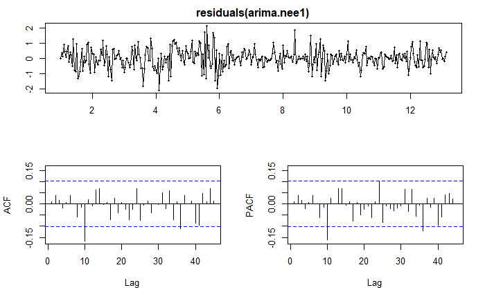

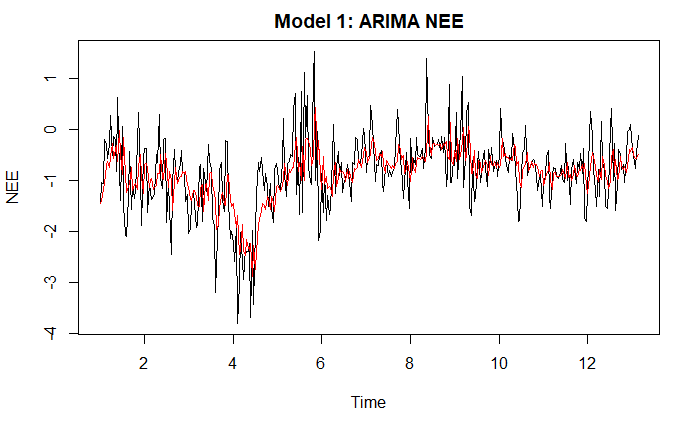

```r
arima.nee2 <-arima(nee , order=c(10,1,3), seasonal= list(order=c(2,0,2))) #accounting for some of the outliers
```

[output not shown]

```r
tsdisplay(residuals(arima.nee2), lag.max= 30)
```

[output not shown]

```r
# You want to minimize AIC
AIC(arima.nee1, arima.nee2)
```

[output not shown]

```r
par(mfrow=c(1,1))
plot(nee , typ="l"); lines(fitted(arima.nee2),col="red")
```

Test of independence at all lags

```r
# Measuring for significant difference from white noise.
# You need a p-value greater than 0.05!
checkresiduals(arima.nee2, lag=36)
```

[output not shown]

```r
par(mfrow=c(1,1))
plot(nee , typ="l", xlab= "Time", ylab= "NEE", main="Model 2: ARIMA NEE"); lines(fitted(arima.nee2),col="red")
```

Forecast plot

```r
plot(forecast(arima.nee2, h=30),xlab = "Time", ylab = "NEE", main = "Forecasts for Model 2: NEE")
```

[output not shown]

1. Create a timeseries object

```r
sal <- ts(mangroves$salinity.max, start= 1, frequency=30)
```

Visualize data:

```r
par(mfrow=c(1,1), mai=c(0.25,0.8,0.1, 0.1))
plot(sal , typ="l", ylab= "Salinity", xlab="")
```

You want to remove any outliers that could bias the model by skewing statistical summaries.

```r
plot(sal , typ="l", ylab= "Salinity", xlab="")
lines(tsclean(sal) , col="red")
```

Clean the timeseries

```r
sal <- tsclean(sal)
```

2. Decompose the time series

```r
sal.d <- decompose(sal, 'multiplicative')
plot(sal.d)
```

3.a. Test for stationarity

```r
# p-value < 0.05 indicates the TS is stationary
adf.test(sal)
```

```r
adf.test(diff(sal))
```

4. Explore correlations.

```r
ccf( diff(sal),nee, na.action = na.pass, lag.max=40, plot=TRUE)
```

5. Explore Models of NEE

```r
arima.nee3 <-auto.arima(nee, xreg=c(diff(sal),0), trace=TRUE)
```

```r
par(mfrow=c(1,1))
plot(nee , typ="l",ylab="NEE",main="Model 3: Difference in Salinity"); lines(fitted(arima.nee3),col="red")
```

```r
#compare to current model
AIC(arima.nee2, arima.nee3 )
```

```r
sal.i <- sal
sal.i[sal.i < 25 ]<- 0
sal.i[sal.i >= 25 ]<- 1
plot(sal.i)
```

Now try adding the extreme salinity indicator into the model to see if this is an improvement:

```r
arima.nee4 <-auto.arima(nee, xreg=sal.i, trace=TRUE)
```

```r
AIC(arima.nee2,arima.nee4 )
```

```r
checkresiduals(arima.nee4, lag=36)
```

```r
par(mfrow=c(1,1))
plot(nee , typ="l",ylab="NEE",main="Model 4: Extreme Salinity Indicator "); lines(fitted(arima.nee4),col="red")
```

Challenge:

Developing another model using: water.tmax

```r
water.tmax<-ts(mangroves$water.tmax,start= 1, frequency = 30)
```

Visualize data

```r
par(mfrow=c(1,1),maic(0.25,0.8,0.1,0.1))
plot(water.tmax, typ="l", ylab="Water_Temp_Max",xlab="")
```

```r
plot(water.tmax)
lines(tsclean(water.tmax),col="red")
```

```r
water.tmax<-tsclean(water.tmax)
```

2.Decompose the timeseries

```r
water.tmax.d<-decompose(water.tmax, 'multiplicative')
plot(water.tmax.d)
```

3.a. Test for stationarity

```r
adf.test(water.tmax)
```

```r
adf.test(diff(water.tmax))

diff_watert<-diff(water.tmax)
```

4. Explore Correlation (look for significant lags)

```r
ccf(diff_watert,nee, na.action=na.pass, lag.max=40, plot=TRUE)
```

5. Explore Models of NEE

```r
arima.nee5wtmax <-auto.arima(nee, xreg = c(diff_watert,0),trace=TRUE)
```

Comparing AIC

```r
AIC(arima.nee1,arima.nee2,arima.nee3,arima.nee4,arima.nee5wtmax)
```

[output not shown]

Check Residuals

```r
checkresiduals(arima.nee5wtmax,lag=36)
```

```r
par(mfrow=c(1,1))
plot(nee , typ="l",ylab="NEE",main="Model 5: Difference in Max Water Temperature"); lines(fitted(arima.nee5wtmax),col="red")
```

Developing another model using: PAR

```r
PAR<-ts(mangroves$par,start= 1, frequency = 30)
```

Visualize data

```r
par(mfrow=c(1,1),maic(0.25,0.8,0.1,0.1))
plot(PAR, typ="l", ylab="PAR",xlab="")
```

```r
plot(PAR)
lines(tsclean(PAR),col="red")
```

```r
PAR<-tsclean(PAR)
```

2.Decompose the timeseries

```r
PAR.d<-decompose(PAR, 'multiplicative')
plot(PAR.d)
```

3.a. Test for stationarity

```r
adf.test(PAR)
```

```r
adf.test(diff(PAR))

diff_PAR<-diff(PAR)
```

4. Explore Correlation (look for significant lags)

```r
ccf(diff_PAR,nee, na.action=na.pass, lag.max=40, plot=TRUE)
```

5. Explore Models of NEE

```r
arima.nee6PAR <-auto.arima(nee, xreg = c(diff_PAR,0),trace=TRUE)
```

Comparing AIC

```r
AIC(arima.nee1,arima.nee2,arima.nee3,arima.nee4,arima.nee5wtmax,arima.nee6PAR)
```

Check Residuals

```r
checkresiduals(arima.nee6PAR,lag=36)
```

Nee with Diff PAR as the red line

```r
par(mfrow=c(1,1))
plot(nee, type="l",ylab="NEE",main="Model 6: Difference in PAR");lines(fitted(arima.nee6PAR),col="red")
```

Developing another model using: Air Temp

```r
tair<-ts(mangroves$tair,start= 1, frequency = 30)
```

Visualize data

```r
par(mfrow=c(1,1),maic(0.25,0.8,0.1,0.1))
plot(tair, typ="l", ylab="Air Temp",xlab="")
```

```r
plot(tair)
lines(tsclean(tair),col="red")
```

```r
tair<-tsclean(tair)
```

2.Decompose the timeseries

```r
tair.d<-decompose(tair, 'multiplicative')
plot(tair.d)
```

3.a. Test for stationarity

```r
adf.test(tair)
```

```r
adf.test(diff(tair))

diff_tair<-diff(tair)
```

4. Explore Correlation (look for significant lags)

```r
ccf(diff_tair,nee, na.action=na.pass, lag.max=40, plot=TRUE)
```

5. Explore Models of NEE

```r
arima.nee7tair<-auto.arima(nee, xreg = c(diff_tair,0),trace=TRUE)
```

Comparing AIC

```r
AIC(arima.nee1,arima.nee2,arima.nee3,arima.nee4,arima.nee5wtmax,arima.nee6PAR,arima.nee7tair)
```

Check Residuals

```r
checkresiduals(arima.nee7tair,lag=36)
```

[output not shown]

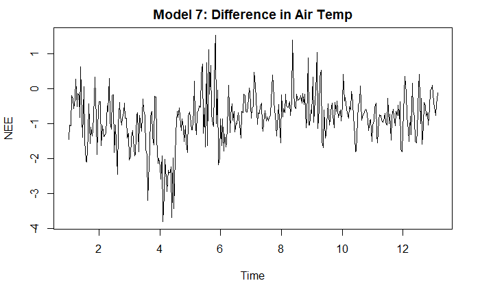

```r
plot(nee, type="l", ylab="NEE",main="Model 7: Difference in Air Temp");lines(fitted(arima.nee7tair),col="red")
```

```r
plot(forecast(arima.nee7tair, h=30),xlab = "Time", ylab = "NEE", main = "Forecasts for Model 7: Difference in Air Temperature")
```

|  | NEE | PAR | Air Temperature | Max Water Temperature | Max Salinity |
| --- | --- | --- | --- | --- | --- |
| Mean | -0.8435 | 4339.6318 | 25.2965 | 28.5526 | 17.5532 |
| Min | -3.7958 | 713.9468 | 11.0457 | 15.9000 | 4.0000 |
| Max | 1.6244 | 6506.1091 | 30.4471 | 34.6000 | 29.0000 |
| Variance | 0.5601 | 1671653.9022 | 13.9678 | 15.8241 | 31.1342 |

```r
write.csv(df_mangroves,"C:/Users/Mere/Desktop/Spring2020_QEcology/Assignment_Workshop_3_Timeseries\\Summary_mangroves_data.csv",row.names = NULL)
```

[output not shown]